# Targets

# Housing targets for older-adult housing

Housing for older adults is an increasingly important issue in an aging society. While the City of Laval has a stock of dedicated older-adult housing now, its need is likely to increase as a larger and larger number of Laval residents are older adults. To identify suitable targets for older-adult housing construction, we rely on a modified version of our general housing target model:

$$RPAC_t = \frac{RPA_{2023}}{MÉ75_{2023}}*MÉ75_t - RPA_{t-1}*(1-TA)$$
Here the number of required RPA completions per year is given by the ratio between the number of RPA units and the number of households headed by someone 75 years or older in 2023 (when this ratio was known), multiplied by the number of households headed by someone 75 years or older expected in the target year $t$, and subject to the usual housing attrition rate $TA$. In other words, we model future need for older-adult housing by assuming that the current supply of such housing is adequate to the population of older adults, and then calculating the number of new units which will be required to maintain this ratio in the future.

We use the ISQ’s projections for households by the age of the household maintainer to establish the future demand for older adult housing. As with its more general household projections, the ISQ produces three scenarios (reference, weak and strong) for household growth by age, which are displayed in Figure TKTK.

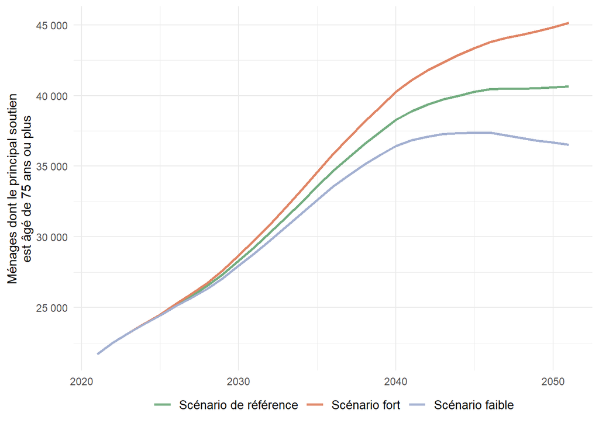

In 2023, there were 0.5184547 units of dedicated older-adult housing for each older-adult household in Laval. For this ratio to remain steady given the expected aging of Laval’s population will require an increase in the number of older-adult housing units. Figure TKTK gives the corresponding total dwelling targets under each of the ISQ’s scenarios.

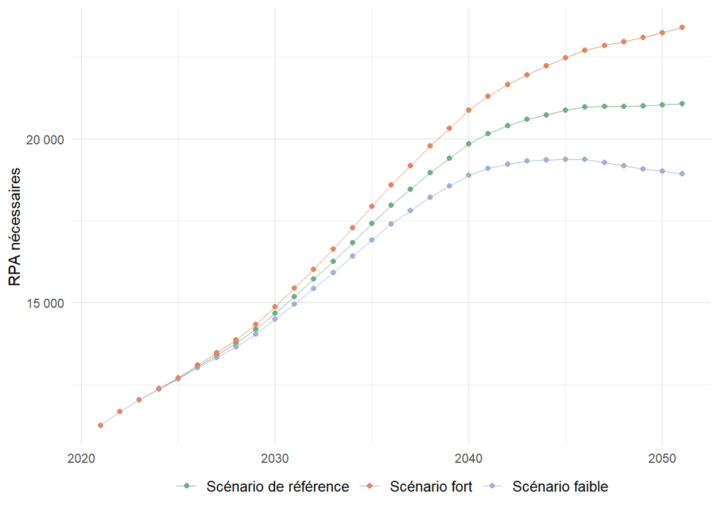

Taking into account already built older-adult housing, and assuming that older-adult housing has the same attrition rate of 0,2 % units per year as the private dwelling stock, we arrive at the targets for necessary older-adult housing completions per year in Figure TKTK. (Minimum annual targets are fixed at zero.) As with the general housing targets, we suggest that the City could adopt a rule of thumb of a two-year lag between starts and completions.

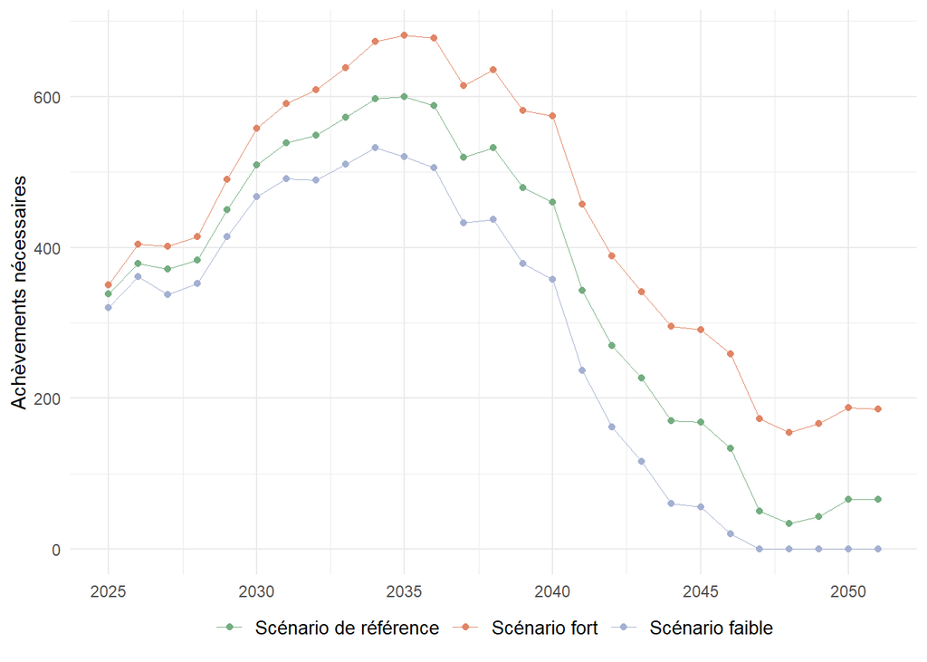